# PML Course Project

## Data Analysis

First, relevant libraries were loaded.

```r
library(caret)
```

Next, the data were loaded using the provided URLs. NA values were imputed onto all empty values within each dataframe.

```r
url_train <- "https://d396qusza40orc.cloudfront.net/predmachlearn/pml-training.csv"
url_test <- "https://d396qusza40orc.cloudfront.net/predmachlearn/pml-testing.csv"


training <- read.csv(url(url_train), na.strings=c("NA",""))
testing <- read.csv(url(url_test), na.strings=c("NA",""))
```

An evaluation of the structure of the training data indicated that there were several columns containing NA values. The colSums function was used to determine how many NA values were in each of these columns. Columns containing NA values included NA values for over 95% of the data observations (19216 / 19622). The first seven columns appear to be related to subject identification and are not relevant to the parameter we are trying to predict.

```r
str(training)
```

```
## 'data.frame':    19622 obs. of  160 variables:
##  $ X                       : int  1 2 3 4 5 6 7 8 9 10 ...
##  $ user_name               : Factor w/ 6 levels "adelmo","carlitos",..: 2 2 2 2 2 2 2 2 2 2 ...
##  $ raw_timestamp_part_1    : int  1323084231 1323084231 1323084231 1323084232 1323084232 1323084232 1323084232 1323084232 1323084232 1323084232 ...
##  $ raw_timestamp_part_2    : int  788290 808298 820366 120339 196328 304277 368296 440390 484323 484434 ...
##  $ cvtd_timestamp          : Factor w/ 20 levels "02/12/2011 13:32",..: 9 9 9 9 9 9 9 9 9 9 ...
##  $ new_window              : Factor w/ 2 levels "no","yes": 1 1 1 1 1 1 1 1 1 1 ...
##  $ num_window              : int  11 11 11 12 12 12 12 12 12 12 ...
##  $ roll_belt               : num  1.41 1.41 1.42 1.48 1.48 1.45 1.42 1.42 1.43 1.45 ...
##  $ pitch_belt              : num  8.07 8.07 8.07 8.05 8.07 8.06 8.09 8.13 8.16 8.17 ...
##  $ yaw_belt                : num  -94.4 -94.4 -94.4 -94.4 -94.4 -94.4 -94.4 -94.4 -94.4 -94.4 ...
##  $ total_accel_belt        : int  3 3 3 3 3 3 3 3 3 3 ...
##  $ kurtosis_roll_belt      : Factor w/ 396 levels "-0.016850","-0.021024",..: NA NA NA NA NA NA NA NA NA NA ...
##  $ kurtosis_picth_belt     : Factor w/ 316 levels "-0.021887","-0.060755",..: NA NA NA NA NA NA NA NA NA NA ...
##  $ kurtosis_yaw_belt       : Factor w/ 1 level "#DIV/0!": NA NA NA NA NA NA NA NA NA NA ...
```

[output cut: 86 more lines]

```r
colSums(is.na(training))
```

```
##                        X                user_name     raw_timestamp_part_1
##                        0                        0                        0
##     raw_timestamp_part_2           cvtd_timestamp               new_window
##                        0                        0                        0
##               num_window                roll_belt               pitch_belt
##                        0                        0                        0
##                 yaw_belt         total_accel_belt       kurtosis_roll_belt
##                        0                        0                    19216
##      kurtosis_picth_belt        kurtosis_yaw_belt       skewness_roll_belt
##                    19216                    19216                    19216
##     skewness_roll_belt.1        skewness_yaw_belt            max_roll_belt
##                    19216                    19216                    19216
##           max_picth_belt             max_yaw_belt            min_roll_belt
##                    19216                    19216                    19216
##           min_pitch_belt             min_yaw_belt      amplitude_roll_belt
##                    19216                    19216                    19216
##     amplitude_pitch_belt       amplitude_yaw_belt     var_total_accel_belt
##                    19216                    19216                    19216
##            avg_roll_belt         stddev_roll_belt            var_roll_belt
##                    19216                    19216                    19216
##           avg_pitch_belt        stddev_pitch_belt           var_pitch_belt
##                    19216                    19216                    19216
##             avg_yaw_belt          stddev_yaw_belt             var_yaw_belt
##                    19216                    19216                    19216
##             gyros_belt_x             gyros_belt_y             gyros_belt_z
##                        0                        0                        0
##             accel_belt_x             accel_belt_y             accel_belt_z
##                        0                        0                        0
##            magnet_belt_x            magnet_belt_y            magnet_belt_z
##                        0                        0                        0
##                 roll_arm                pitch_arm                  yaw_arm
##                        0                        0                        0
##          total_accel_arm            var_accel_arm             avg_roll_arm
##                        0                    19216                    19216
##          stddev_roll_arm             var_roll_arm            avg_pitch_arm
##                    19216                    19216                    19216
##         stddev_pitch_arm            var_pitch_arm              avg_yaw_arm
##                    19216                    19216                    19216
##           stddev_yaw_arm              var_yaw_arm              gyros_arm_x
##                    19216                    19216                        0
```

[output cut: 53 more lines]

```
##                    19216                        0                    19216
##         avg_roll_forearm      stddev_roll_forearm         var_roll_forearm
##                    19216                    19216                    19216
##        avg_pitch_forearm     stddev_pitch_forearm        var_pitch_forearm
##                    19216                    19216                    19216
##          avg_yaw_forearm       stddev_yaw_forearm          var_yaw_forearm
##                    19216                    19216                    19216
##          gyros_forearm_x          gyros_forearm_y          gyros_forearm_z
##                        0                        0                        0
##          accel_forearm_x          accel_forearm_y          accel_forearm_z
##                        0                        0                        0
##         magnet_forearm_x         magnet_forearm_y         magnet_forearm_z
##                        0                        0                        0
##                   classe
##                        0
```

As a result, columns containing mostly NA values and columns related to test subject identification (Columns 1 - 7) were dropped from each of the datasets:

```r
training_clean <- training[, 8:length(training)]
training_clean <- training_clean[colSums(is.na(training_clean)) == 0]

testing_clean <- testing[, 8:length(testing)]
testing_clean <- testing_clean[colSums(is.na(testing_clean)) == 0]
```

The remaining columns were analyzed to verify that none of them have a near-zero variance:

```r
nearZeroVar(training_clean, saveMetrics=TRUE)
```

```
##                      freqRatio percentUnique zeroVar   nzv
## roll_belt             1.101904     6.7781062   FALSE FALSE
## pitch_belt            1.036082     9.3772296   FALSE FALSE
## yaw_belt              1.058480     9.9734991   FALSE FALSE
## total_accel_belt      1.063160     0.1477933   FALSE FALSE
## gyros_belt_x          1.058651     0.7134849   FALSE FALSE
## gyros_belt_y          1.144000     0.3516461   FALSE FALSE
## gyros_belt_z          1.066214     0.8612782   FALSE FALSE
## accel_belt_x          1.055412     0.8357966   FALSE FALSE
## accel_belt_y          1.113725     0.7287738   FALSE FALSE
## accel_belt_z          1.078767     1.5237998   FALSE FALSE
## magnet_belt_x         1.090141     1.6664968   FALSE FALSE
## magnet_belt_y         1.099688     1.5187035   FALSE FALSE
## magnet_belt_z         1.006369     2.3290184   FALSE FALSE
## roll_arm             52.338462    13.5256345   FALSE FALSE
## pitch_arm            87.256410    15.7323412   FALSE FALSE
## yaw_arm              33.029126    14.6570176   FALSE FALSE
## total_accel_arm       1.024526     0.3363572   FALSE FALSE
## gyros_arm_x           1.015504     3.2769341   FALSE FALSE
## gyros_arm_y           1.454369     1.9162165   FALSE FALSE
## gyros_arm_z           1.110687     1.2638875   FALSE FALSE
## accel_arm_x           1.017341     3.9598410   FALSE FALSE
## accel_arm_y           1.140187     2.7367241   FALSE FALSE
## accel_arm_z           1.128000     4.0362858   FALSE FALSE
## magnet_arm_x          1.000000     6.8239731   FALSE FALSE
## magnet_arm_y          1.056818     4.4439914   FALSE FALSE
## magnet_arm_z          1.036364     6.4468454   FALSE FALSE
## roll_dumbbell         1.022388    84.2065029   FALSE FALSE
## pitch_dumbbell        2.277372    81.7449801   FALSE FALSE
## yaw_dumbbell          1.132231    83.4828254   FALSE FALSE
## total_accel_dumbbell  1.072634     0.2191418   FALSE FALSE
## gyros_dumbbell_x      1.003268     1.2282132   FALSE FALSE
## gyros_dumbbell_y      1.264957     1.4167771   FALSE FALSE
## gyros_dumbbell_z      1.060100     1.0498420   FALSE FALSE
## accel_dumbbell_x      1.018018     2.1659362   FALSE FALSE
## accel_dumbbell_y      1.053061     2.3748853   FALSE FALSE
## accel_dumbbell_z      1.133333     2.0894914   FALSE FALSE
## magnet_dumbbell_x     1.098266     5.7486495   FALSE FALSE
## magnet_dumbbell_y     1.197740     4.3012945   FALSE FALSE
## magnet_dumbbell_z     1.020833     3.4451126   FALSE FALSE
## roll_forearm         11.589286    11.0895933   FALSE FALSE
## pitch_forearm        65.983051    14.8557741   FALSE FALSE
## yaw_forearm          15.322835    10.1467740   FALSE FALSE
## total_accel_forearm   1.128928     0.3567424   FALSE FALSE
## gyros_forearm_x       1.059273     1.5187035   FALSE FALSE
## gyros_forearm_y       1.036554     3.7763735   FALSE FALSE
## gyros_forearm_z       1.122917     1.5645704   FALSE FALSE
## accel_forearm_x       1.126437     4.0464784   FALSE FALSE
## accel_forearm_y       1.059406     5.1116094   FALSE FALSE
## accel_forearm_z       1.006250     2.9558659   FALSE FALSE
## magnet_forearm_x      1.012346     7.7667924   FALSE FALSE
## magnet_forearm_y      1.246914     9.5403119   FALSE FALSE
## magnet_forearm_z      1.000000     8.5771073   FALSE FALSE
## classe                1.469581     0.0254816   FALSE FALSE
```

None of the remaining columns have a near-zero variance and were thus kept in the dataset for analysis.

### Cross Validation

Since we do not have the correct predictions from the testing data available, cross validation was used to evaluate model performance. A k-fold cross validation procedure was used, and a value of k = 10 was selected. The same set of folds was used for evaluation of each model

```r
set.seed(1000)
k_val <- 10
flds <- createFolds(training_clean$classe, k=k_val, list=TRUE)
```

## Model Evaluation

Performance of four (4) models was compared:

- Linear SVM
- Random Forest
- Classification Tree
- Boosting

For each of these models, a model was fit to folds 2 - 10 of the cross validation sets. Each of these models was then used to predict values contained in fold 1. The resulting accuracy was calculated for each fold, and the mean accuracy was calculated for the entire training set. The mean accuracy was then used to calculate the mean out of sample error. This value was used to compare performance of each of the four models.

### Model 1: Linear SVM

```r
linearSvm_accuracy <- vector()
tester <- training_clean[flds[[1]],]

for (i in 2:k_val) {
    trainer <- training_clean[flds[[i]],]
    model <- train(classe ~ ., data=trainer, method="svmLinear")
    pred <- predict(model, tester)
    linearSvm_accuracy <- c(linearSvm_accuracy,confusionMatrix(pred, tester$classe)$overall[1])
}

mean(linearSvm_accuracy)
```

```
## [1] 0.7428361
```

```r
linearSvm_error <- 1 - mean(linearSvm_accuracy)
```

### Model 2: Random Forest

```r
rf_accuracy <- vector()

for (i in 2:k_val) {
    trainer <- training_clean[flds[[i]],]
    model <- train(classe ~ ., data=trainer, method="rf")
    pred <- predict(model, tester)
    rf_accuracy <- c(rf_accuracy,confusionMatrix(pred, tester$classe)$overall[1])
}

mean(rf_accuracy)
```

```
## [1] 0.9481821
```

```r
rf_error <- 1 - mean(rf_accuracy)
```

### Model 3: Classification Tree

Cross Validation

```r
rpart_accuracy <- vector()

for (i in 2:k_val) {
    trainer <- training_clean[flds[[i]],]
    model <- train(classe ~ ., data=trainer, method="rpart")
    pred <- predict(model, tester)
    rpart_accuracy <- c(rpart_accuracy,confusionMatrix(pred, tester$classe)$overall[1])
}

mean(rpart_accuracy)
```

```
## [1] 0.5060029
```

```r
rpart_error <- 1 - mean(rpart_accuracy)
```

### Model 4: Boosting

```r
gbm_accuracy <- vector()

for (i in 2:k_val) {
    trainer <- training_clean[flds[[i]],]
    model <- train(classe ~ ., data=trainer, method="gbm", verbose=FALSE)
    pred <- predict(model, tester)
    gbm_accuracy <- c(gbm_accuracy,confusionMatrix(pred, tester$classe)$overall[1])
}

mean(gbm_accuracy)
```

```
## [1] 0.9235474
```

```r
gbm_error <- 1 - mean(gbm_accuracy)
```

## Model Comparison

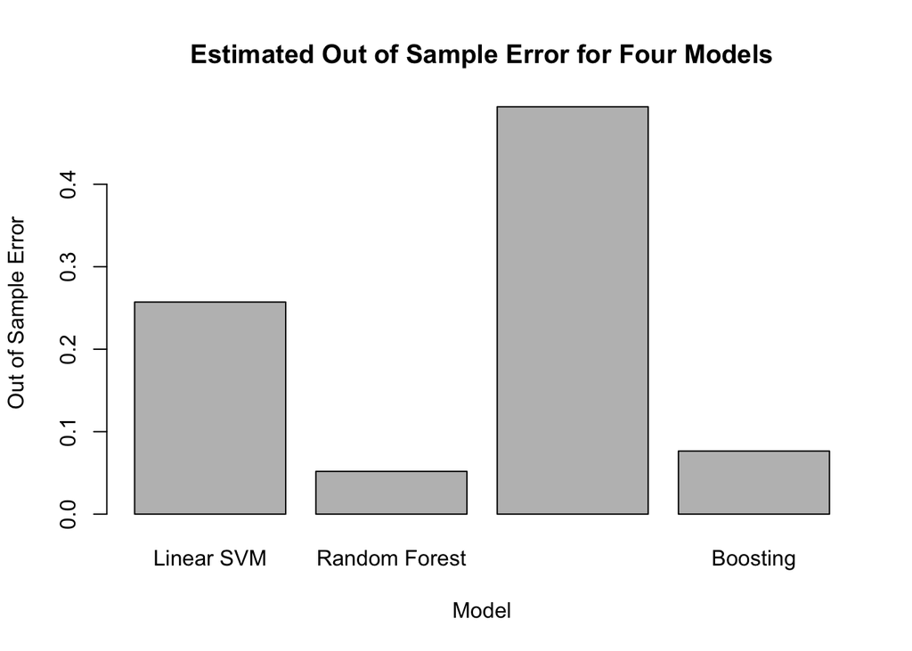

```r
barplot(c(linearSvm_error, rf_error, rpart_error, gbm_error), names.arg=c("Linear SVM", "Random Forest", "Classification Tree", "Boosting"), main="Estimated Out of Sample Error for Four Models", xlab="Model", ylab="Out of Sample Error")
```

Based on this comparison, the Random Forest model contained the lowest estimated out of sample error. As a result, this model was selected for implementation across the full training dataset.

## Random Forest Model Creation and Prediction:

```r
mod_rf <- train(classe ~ ., data=training_clean, method="rf", preProcess=c("center", "scale"), trControl=trainControl(method="cv", number=10))

rf_pred <- predict(mod_rf, testing_clean)

rf_pred
```

```
##  [1] B A B A A E D B A A B C B A E E A B B B
## Levels: A B C D E
```